# Condensed Analyses for Science Report

Lauren E Johnson

11/17/2022

#### **1. Load the data**

Load 3D brain coordinates for the wholebrain and each region: telencephalon (tel), diencephalon (dien), mesencephalon (mes), cerebellum (cere), and medulla oblongata (medob). Load trait data. Load phylogenetic tree.

```r
# Brain coordinate data
load(here::here('data/whole_brain_coords_S1.Rda')) # wholebrain
load(here::here('data/tel_coords_S1.Rda'))         # tel
load(here::here('data/dien_coords_S1.Rda'))        # dien
load(here::here('data/mes_coords_S1.Rda'))         # mes
load(here::here('data/cere_coords_S1.Rda'))        # cere
load(here::here('data/medob_coords_S1.Rda'))       # medob

# Trait data
load(here::here('data/lizard_trait_data.Rda'))

# Phylogenetic tree data
load(here::here('data/lizard_tree.Rda'))
```

#### **2. Whole brain size and shape analysis**

**Part 1.** Perform a **generalize procrustes analysis (GPA)** with `gpagen` on the coordinate data. GPA aligns all the species coordinates in the most optimal way (e.g., removing scale, orientation, and position) so that we can better compare the shapes of each species to each other.

```r
library(geomorph)

wb.gpa <- gpagen(wholebrain, ProcD = T, verbose = T, print.progress = F)
```

**Part 2.** Create a geomorph data frame that contains the Procrustes coordinates and the trait data. This will be used in subsequent analyses.

```r
wb.gdf <- geomorph.data.frame(wb.gpa, trait)
```

**Part 3.** Run a **Phylogenetic ANOVA/regression (PGLS)** with `procD.pgls` to test for correlations between ecological traits and whole brain size and shape.

**Whole Brain Shape:**  
note: we included Csize as a covariate since shape often covaries with size. Refer to supplementary information for how much shape variation is explained by size.

```r
pgls_wb.shape <- procD.pgls(coords ~ Csize + abslatitude + precip_seasonality + temp_seasonality + microhabitat + activity_time + foraging_mode, phy = lzrd_tree, SS.type = "III", data = wb.gdf, print.progress = F)
```

**Whole Brain Size:**

```r
pgls_wb.size <- procD.pgls(Csize ~ abslatitude + precip_seasonality + temp_seasonality + microhabitat + activity_time + foraging_mode, phy = lzrd_tree, SS.type = "III", data = wb.gdf, print.progress = F)
```

Whole Brain Shape

| Source | df<sup>1</sup> | SS<sup>2</sup> | MS<sup>3</sup> | Rsq | F | Z | p-value<sup>4</sup> |
| --- | --- | --- | --- | --- | --- | --- | --- |
| Csize | 1 | 0.0011 | 0.0011 | 0.061 | 1.83 | 1.12 | 0.138 |
| abslatitude | 1 | 0.0008 | 0.0008 | 0.043 | 1.29 | 0.66 | 0.261 |
| precip_seasonality | 1 | 0.0003 | 0.0003 | 0.019 | 0.57 | −0.51 | 0.681 |
| temp_seasonality | 1 | 0.0003 | 0.0003 | 0.019 | 0.59 | −0.41 | 0.646 |
| microhabitat | 2 | 0.0006 | 0.0003 | 0.033 | 0.50 | −1.15 | 0.871 |
| activity_time | 2 | 0.0009 | 0.0005 | 0.053 | 0.79 | −0.19 | 0.568 |
| foraging_mode | 1 | 0.0010 | 0.0010 | 0.057 | 1.73 | 1.03 | 0.143 |
| Residuals | 18 | 0.0107 | 0.0006 | 0.599 |  |  |  |
| Total | 27 | 0.0179 |  |  |  |  |  |

<sup>1</sup> df, degree of freedom.  
<sup>2</sup> SS, sum of squares.  
<sup>3</sup> MS, mean squares.  
<sup>4</sup> Significant values (p-value < 0.05) from permutation tests (1,000 permutation rounds) are bolded.

Whole Brain Size

| Source | df<sup>1</sup> | SS<sup>2</sup> | MS<sup>3</sup> | Rsq | F | Z | p-value<sup>4</sup> |
| --- | --- | --- | --- | --- | --- | --- | --- |
| abslatitude | 1 | 2,445,811 | 2,445,811 | 0.115 | 7.79 | 2.13 | 0.015 |
| precip_seasonality | 1 | 1,841,641 | 1,841,641 | 0.086 | 5.87 | 1.84 | 0.031 |
| temp_seasonality | 1 | 447,093 | 447,093 | 0.021 | 1.42 | 0.71 | 0.262 |
| microhabitat | 2 | 3,550,208 | 1,775,104 | 0.166 | 5.66 | 2.24 | 0.019 |
| activity_time | 2 | 4,357,270 | 2,178,635 | 0.204 | 6.94 | 2.32 | 0.009 |
| foraging_mode | 1 | 103,192 | 103,192 | 0.005 | 0.33 | −0.19 | 0.582 |
| Residuals | 19 | 5,964,085 | 313,899 | 0.280 |  |  |  |
| Total | 27 | 21,335,238 |  |  |  |  |  |

<sup>1</sup> df, degree of freedom.  
<sup>2</sup> SS, sum of squares.  
<sup>3</sup> MS, mean squares.  
<sup>4</sup> Significant values (p-value < 0.05) from permutation tests (1,000 permutation rounds) are bolded.

**Effect size** of each ecological variable on Csize. In other words, the slope.

| (Intercept) | 3.005725e+04 |
| --- | --- |
| abslatitude | -3.835681e+02 |
| precip_seasonality | -1.338642e+02 |
| temp_seasonality | 7.831459e-01 |
| microhabitatScansorial | 1.779375e+04 |
| microhabitatTerrestrial | 1.180822e+04 |
| activity_timeDiurnal | -1.103175e+04 |
| activity_timeNocturnal | 3.649554e+03 |
| foraging_modesit_and_wait | 1.926093e+03 |

**Fig 1.** Foraging Mode

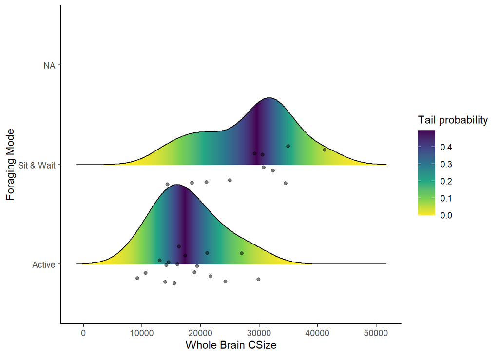

**Fig S1.** Activity Time

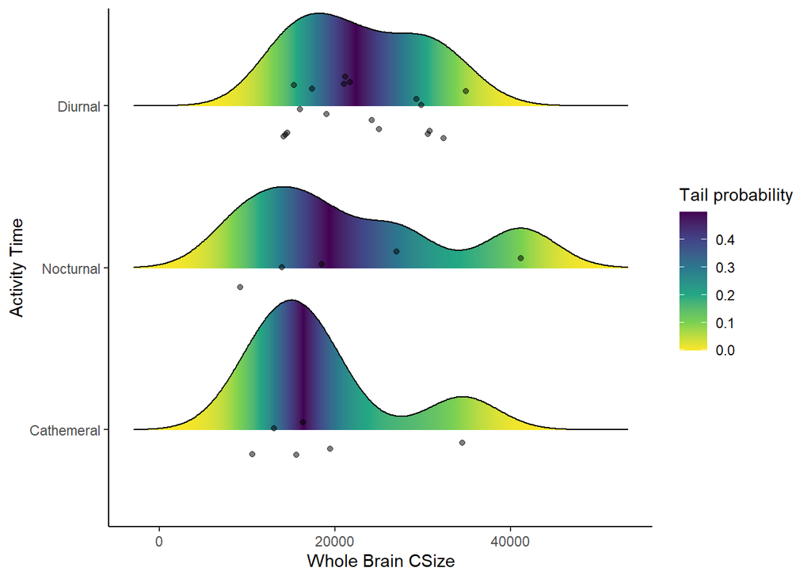

**Fig S2.** Microhabitat

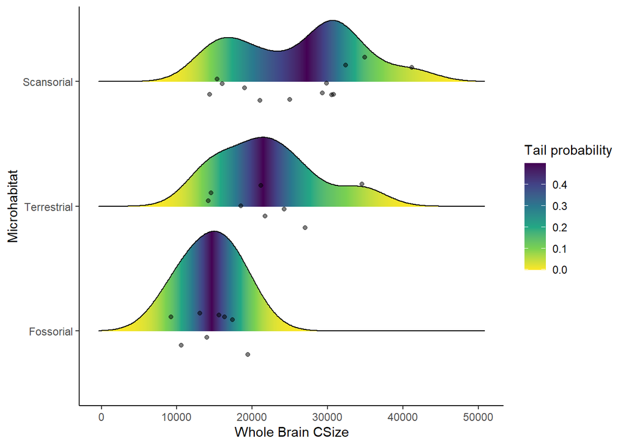

**Part 4.** To visualize shape variation, we performed a **principle components analysis with phylogeny considered (phyloPCA)** with `gm.prcomp` on the Procrustes shape coordinates and plotted them.

```r
wb.pca <- gm.prcomp(wb.gpa$coords, phy = lzrd_tree, GLS = TRUE)
```

```r
kable(summary(wb.pca))
```

[output not shown]

[output cut: 54 more lines]

[output not shown]

|  | Comp1 | Comp2 | Comp3 | Comp4 | Comp5 | Comp6 | Comp7 | Comp8 | Comp9 | Comp10 | Comp11 | Comp12 | Comp13 | Comp14 | Comp15 | Comp16 | Comp17 | Comp18 | Comp19 | Comp20 | Comp21 | Comp22 | Comp23 | Comp24 | Comp25 | Comp26 | Comp27 | Comp28 |
| --- | --- | --- | --- | --- | --- | --- | --- | --- | --- | --- | --- | --- | --- | --- | --- | --- | --- | --- | --- | --- | --- | --- | --- | --- | --- | --- | --- | --- |
| Eigenvalues | 0.0001317 | 0.0000717 | 0.0000307 | 0.0000291 | 0.0000179 | 0.0000140 | 0.0000118 | 0.0000093 | 0.0000082 | 0.0000074 | 0.0000054 | 0.0000053 | 0.0000046 | 0.0000039 | 0.0000033 | 0.0000025 | 0.0000025 | 0.0000022 | 0.0000021 | 0.0000018 | 0.0000014 | 0.0000011 | 0.0000011 | 0.0000008 | 0.0000006 | 0.0000006 | 0.0000004 | 0.0000003 |
| Proportion of Variance | 0.3544203 | 0.1929130 | 0.0825388 | 0.0783851 | 0.0482440 | 0.0375729 | 0.0317603 | 0.0251084 | 0.0219629 | 0.0198331 | 0.0144375 | 0.0141611 | 0.0124784 | 0.0105330 | 0.0089140 | 0.0067737 | 0.0067134 | 0.0060399 | 0.0057724 | 0.0048633 | 0.0036568 | 0.0029195 | 0.0028630 | 0.0022177 | 0.0016094 | 0.0015121 | 0.0010520 | 0.0007437 |
| Cumulative Proportion | 0.3544203 | 0.5473333 | 0.6298721 | 0.7082572 | 0.7565012 | 0.7940741 | 0.8258344 | 0.8509428 | 0.8729057 | 0.8927388 | 0.9071763 | 0.9213374 | 0.9338159 | 0.9443489 | 0.9532629 | 0.9600366 | 0.9667500 | 0.9727899 | 0.9785623 | 0.9834257 | 0.9870825 | 0.9900020 | 0.9928650 | 0.9950827 | 0.9966921 | 0.9982042 | 0.9992563 | 1.0000000 |

|  | Comp1 | Comp2 | Comp3 | Comp4 | Comp5 | Comp6 | Comp7 | Comp8 | Comp9 | Comp10 | Comp11 | Comp12 | Comp13 | Comp14 | Comp15 | Comp16 | Comp17 | Comp18 | Comp19 | Comp20 | Comp21 | Comp22 | Comp23 | Comp24 | Comp25 | Comp26 | Comp27 | Comp28 |
| --- | --- | --- | --- | --- | --- | --- | --- | --- | --- | --- | --- | --- | --- | --- | --- | --- | --- | --- | --- | --- | --- | --- | --- | --- | --- | --- | --- | --- |
| Tips Dispersion | 0.0096812 | 0.0071479 | 0.0014246 | 0.0044987 | 0.0014741 | 0.0014429 | 0.0011559 | 0.0009711 | 0.0011684 | 0.0009705 | 0.0005768 | 0.0005462 | 0.0003536 | 0.0003276 | 0.0004410 | 0.0005191 | 0.0002321 | 0.0002611 | 0.0001932 | 0.0003044 | 0.0002052 | 0.0003166 | 0.0001299 | 0.0001528 | 0.0001169 | 0.0001043 | 0.0001121 | 0.0001981 |
| Proportion Tips Dispersion | 0.2763974 | 0.2040727 | 0.0406733 | 0.1284372 | 0.0420852 | 0.0411955 | 0.0330006 | 0.0277243 | 0.0333577 | 0.0277071 | 0.0164683 | 0.0155947 | 0.0100965 | 0.0093538 | 0.0125900 | 0.0148203 | 0.0066261 | 0.0074553 | 0.0055168 | 0.0086895 | 0.0058595 | 0.0090382 | 0.0037073 | 0.0043632 | 0.0033382 | 0.0029777 | 0.0031991 | 0.0056547 |
| Cumulative Tips Dispersion | 0.2763974 | 0.4804701 | 0.5211434 | 0.6495806 | 0.6916658 | 0.7328613 | 0.7658619 | 0.7935861 | 0.8269438 | 0.8546509 | 0.8711192 | 0.8867138 | 0.8968103 | 0.9061641 | 0.9187541 | 0.9335743 | 0.9402005 | 0.9476558 | 0.9531726 | 0.9618621 | 0.9677216 | 0.9767598 | 0.9804671 | 0.9848304 | 0.9881686 | 0.9911462 | 0.9943453 | 1.0000000 |
| Ancestors Dispersion | 0.0014334 | 0.0014392 | 0.0000512 | 0.0015519 | 0.0002615 | 0.0003821 | 0.0002526 | 0.0002916 | 0.0002873 | 0.0003394 | 0.0001042 | 0.0000684 | 0.0000241 | 0.0000323 | 0.0001142 | 0.0002345 | 0.0000233 | 0.0000730 | 0.0000146 | 0.0000929 | 0.0000626 | 0.0001461 | 0.0000252 | 0.0000432 | 0.0000373 | 0.0000271 | 0.0000497 | 0.0001428 |
| Proportion Ancestors Dispersion | 0.1884629 | 0.1892232 | 0.0067366 | 0.2040493 | 0.0343786 | 0.0502344 | 0.0332074 | 0.0383350 | 0.0377778 | 0.0446292 | 0.0137020 | 0.0089974 | 0.0031728 | 0.0042526 | 0.0150162 | 0.0308354 | 0.0030598 | 0.0095989 | 0.0019150 | 0.0122102 | 0.0082328 | 0.0192030 | 0.0033196 | 0.0056778 | 0.0049045 | 0.0035609 | 0.0065375 | 0.0187691 |
| Cumulative Ancestors Dispersion | 0.1884629 | 0.3776861 | 0.3844227 | 0.5884720 | 0.6228505 | 0.6730850 | 0.7062924 | 0.7446274 | 0.7824052 | 0.8270344 | 0.8407364 | 0.8497338 | 0.8529066 | 0.8571592 | 0.8721755 | 0.9030108 | 0.9060707 | 0.9156696 | 0.9175846 | 0.9297948 | 0.9380276 | 0.9572305 | 0.9605501 | 0.9662279 | 0.9711325 | 0.9746933 | 0.9812309 | 1.0000000 |

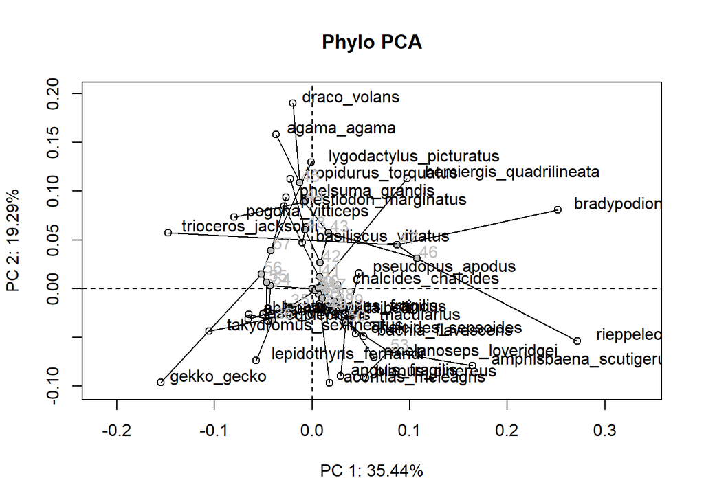

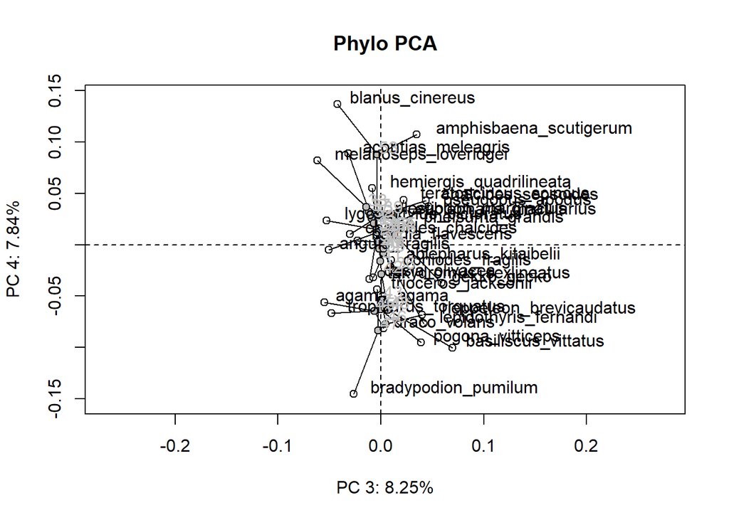